# Hands-On Tutorials for Covariate Adjustment in Randomized Trials

### 2.3 Apply Column Labels for Readability

```r
# Apply labels to Variables
labelled::var_label(sim_miii_full$age) <-
  "Age at Presentation (y)"
labelled::var_label(sim_miii_full$male) <-
  "Sex"
labelled::var_label(sim_miii_full$hx_cvd) <-
  "Hx Cardiovascular Disease"
labelled::var_label(sim_miii_full$hx_hyperlipidemia) <-
  "Hx Hyperlipidemia"
labelled::var_label(sim_miii_full$on_anticoagulants) <-
  "On Anticoagulants: Presentation"
labelled::var_label(sim_miii_full$on_antiplatelets) <-
  "On Antiplatelets: Presentation"

labelled::var_label(sim_miii_full$ich_location) <-
  "ICH Location"
labelled::var_label(sim_miii_full$ich_s_volume) <-
  "ICH Volume (mL): Stability"
labelled::var_label(sim_miii_full$ivh_s_volume) <-
  "IVH Volume (mL): Stability"
labelled::var_label(sim_miii_full$gcs_category) <-
  "Glasgow Coma Scale: Presentation"

labelled::var_label(sim_miii_full$mrs_30d) <-
  "Modified Rankin Scale: 30 Days"
labelled::var_label(sim_miii_full$mrs_180d) <-
  "Modified Rankin Scale: 180 Days"
labelled::var_label(sim_miii_full$mrs_365d) <-
  "Modified Rankin Scale: 365 Days"
labelled::var_label(sim_miii_full$mrs_365d_binary) <-
  "Modified Rankin Scale < 4: 365 Days"
labelled::var_label(sim_miii_full$mrs_365d_binary_factor) <-
  "Modified Rankin Scale < 4: 365 Days"
```

## 3 Study Descriptives

In this section, we tabulate the baseline covariates, assess imbalance using standardized differences between treatment arms, tabulate our outcomes, and calculate crude estimates of the risk difference, relative risk, and odds ratio.

First, let’s create the subset of data

```r
sim_miii <-
  sim_miii_full %>%
  dplyr::slice(1:n_total_fixed) %>%
  as.data.frame()
```

### 3.1 Covariates: By Treatment, Aggregate

```r
table1::table1(
  x = ~
    age + male + hx_cvd + hx_hyperlipidemia +
    on_anticoagulants + on_antiplatelets +
    ich_location + ich_s_volume + ivh_s_volume +
    gcs_category |
    arm,
  data = sim_miii
)
```

|  | medical (N=249) | surgical (N=249) | Overall (N=498) |
| --- | --- | --- | --- |
| Age at Presentation (y) |  |  |  |
| Mean (SD) | 60.6 (12.9) | 60.0 (12.5) | 60.3 (12.7) |
| Median [Min, Max] | 62.0 [28.0, 85.0] | 61.0 [35.0, 88.0] | 62.0 [28.0, 88.0] |
| Sex |  |  |  |
| 0. Female | 100 (40.2%) | 93 (37.3%) | 193 (38.8%) |
| 1. Male | 149 (59.8%) | 156 (62.7%) | 305 (61.2%) |
| Hx Cardiovascular Disease |  |  |  |
| 0. No | 215 (86.3%) | 210 (84.3%) | 425 (85.3%) |
| 1. Yes | 34 (13.7%) | 39 (15.7%) | 73 (14.7%) |
| Hx Hyperlipidemia |  |  |  |
| 0. No | 147 (59.0%) | 158 (63.5%) | 305 (61.2%) |
| 1. Yes | 102 (41.0%) | 91 (36.5%) | 193 (38.8%) |
| On Anticoagulants: Presentation |  |  |  |
| 0. No | 232 (93.2%) | 236 (94.8%) | 468 (94.0%) |
| 1. Yes | 17 (6.8%) | 13 (5.2%) | 30 (6.0%) |
| On Antiplatelets: Presentation |  |  |  |
| 0. No | 178 (71.5%) | 164 (65.9%) | 342 (68.7%) |
| 1. Yes | 71 (28.5%) | 85 (34.1%) | 156 (31.3%) |
| ICH Location |  |  |  |
| Deep | 155 (62.2%) | 159 (63.9%) | 314 (63.1%) |
| Lobar | 94 (37.8%) | 90 (36.1%) | 184 (36.9%) |
| ICH Volume (mL): Stability |  |  |  |
| Mean (SD) | 48.0 (17.3) | 47.4 (16.2) | 47.7 (16.7) |
| Median [Min, Max] | 45.9 [15.2, 112] | 47.0 [12.9, 106] | 46.4 [12.9, 112] |
| IVH Volume (mL): Stability |  |  |  |
| Mean (SD) | 2.47 (3.97) | 2.10 (3.40) | 2.29 (3.70) |
| Median [Min, Max] | 0 [0, 32.0] | 0 [0, 18.0] | 0 [0, 32.0] |
| Glasgow Coma Scale: Presentation |  |  |  |
| 1. Severe (3-8) | 71 (28.5%) | 63 (25.3%) | 134 (26.9%) |
| 2. Moderate (9-12) | 111 (44.6%) | 101 (40.6%) | 212 (42.6%) |
| 3. Mild (13-15) | 67 (26.9%) | 85 (34.1%) | 152 (30.5%) |

### 3.2 Covariate Balance

```r
cobalt::bal.tab(
  x =
    sim_miii %>%
    dplyr::select(
      age, male, on_antiplatelets, ich_location, ich_s_volume,
      ivh_s_volume, gcs_category
    ),
  treat = sim_miii$arm,
  binary = "std",
  continuous = "std",
  s.d.denom = "pooled"
)
```

```
## Balance Measures
##                                    Type Diff.Un
## age                             Contin. -0.0471
## male_1. Male                     Binary  0.0577
## on_antiplatelets_1. Yes          Binary  0.1214
## ich_location_Lobar               Binary -0.0333
## ich_s_volume                    Contin. -0.0311
## ivh_s_volume                    Contin. -0.1022
## gcs_category_1. Severe (3-8)     Binary -0.0725
## gcs_category_2. Moderate (9-12)  Binary -0.0813
## gcs_category_3. Mild (13-15)     Binary  0.1575
##
## Sample sizes
##     medical surgical
## All     249      249
```

### 3.3 Outcomes:

```r
table1::table1(
  x = ~
    mrs_365d +
    mrs_365d_binary_factor |
    arm,
  data = sim_miii
)
```

|  | medical (N=249) | surgical (N=249) | Overall (N=498) |
| --- | --- | --- | --- |
| Modified Rankin Scale: 365 Days |  |  |  |
| 0-1 | 13 (5.2%) | 27 (10.8%) | 40 (8.0%) |
| 2 | 25 (10.0%) | 39 (15.7%) | 64 (12.9%) |
| 3 | 73 (29.3%) | 53 (21.3%) | 126 (25.3%) |
| 4 | 42 (16.9%) | 54 (21.7%) | 96 (19.3%) |
| 5 | 30 (12.0%) | 33 (13.3%) | 63 (12.7%) |
| 6 | 64 (25.7%) | 40 (16.1%) | 104 (20.9%) |
| Missing | 2 (0.8%) | 3 (1.2%) | 5 (1.0%) |
| Modified Rankin Scale < 4: 365 Days |  |  |  |
| 0 | 136 (54.6%) | 127 (51.0%) | 263 (52.8%) |
| 1 | 111 (44.6%) | 119 (47.8%) | 230 (46.2%) |
| Missing | 2 (0.8%) | 3 (1.2%) | 5 (1.0%) |

### 3.4 Crude Estimates

```r
y1_hat <-
  with(
    data = subset(sim_miii, arm == "surgical"),
    mean(mrs_365d_binary, na.rm = TRUE)
  )
y0_hat <-
  with(
    data = subset(sim_miii, arm == "medical"),
    mean(mrs_365d_binary, na.rm = TRUE)
  )

# Risk Difference
y1_hat - y0_hat
```

```
## [1] 0.03434712
```

```r
# Risk Ratio
y1_hat/y0_hat
```

```
## [1] 1.07643
```

```r
# Odds Ratio
(y1_hat*(1 - y0_hat))/(y0_hat*(1 - y1_hat))
```

```
## [1] 1.148046
```

## 4 Unadjusted Analysis

### 4.1 Fitting Logistic Model

```r
mrs_unadjusted_logistic_glm <-
  stats::glm(
    formula = mrs_365d_binary ~ arm,
    data = sim_miii,
    family = binomial(link = "logit")
  )

summary(mrs_unadjusted_logistic_glm)
```

```
##
## Call:
## stats::glm(formula = mrs_365d_binary ~ arm, family = binomial(link = "logit"),
##     data = sim_miii)
##
## Coefficients:
##             Estimate Std. Error z value Pr(>|z|)
## (Intercept)  -0.2031     0.1279  -1.588    0.112
## armsurgical   0.1381     0.1807   0.764    0.445
##
## (Dispersion parameter for binomial family taken to be 1)
##
##     Null deviance: 681.23  on 492  degrees of freedom
## Residual deviance: 680.65  on 491  degrees of freedom
##   (5 observations deleted due to missingness)
## AIC: 684.65
##
## Number of Fisher Scoring iterations: 3
```

### 4.2 Generating Unadjusted Predictions

```r
pr_outcome_unadj_control <-
  stats::predict(
    object = mrs_unadjusted_logistic_glm,
    newdata =
      within(data = sim_miii,
             expr = {arm = "medical"}),
    type = "response"
  )

pr_outcome_unadj_treatment <-
  stats::predict(
    object = mrs_unadjusted_logistic_glm,
    newdata =
      within(data = sim_miii,
             expr = {arm = "surgical"}),
    type = "response"
  )

table(pr_outcome_unadj_control)
```

```
## pr_outcome_unadj_control
## 0.449392712693829
##               498
```

```r
table(pr_outcome_unadj_treatment)
```

```
## pr_outcome_unadj_treatment
## 0.483739837398429
##               498
```

### 4.3 Average & Contrast Predictions

```r
e_y_0_unadj <- mean(pr_outcome_unadj_control)
e_y_1_unadj <- mean(pr_outcome_unadj_treatment)

# Risk Difference
e_y_1_unadj - e_y_0_unadj
```

```
## [1] 0.03434712
```

```r
# Relative Risk
e_y_1_unadj/e_y_0_unadj
```

```
## [1] 1.07643
```

```r
# Odds Ratio
(e_y_1_unadj*(1 - e_y_0_unadj))/
  (e_y_0_unadj*(1 - e_y_1_unadj))
```

```
## [1] 1.148046
```

### 4.4 Compare with Logistic GLM

```r
unadj_glm_beta <- coef(mrs_unadjusted_logistic_glm)
pr_medical <-
  plogis(unadj_glm_beta["(Intercept)"])

pr_surgical <-
  plogis(unadj_glm_beta["(Intercept)"] +
           unadj_glm_beta["armsurgical"])

pr_surgical - pr_medical # Risk Difference
```

```
## (Intercept)
##  0.03434712
```

```r
pr_surgical/pr_medical # Relative Risk
```

```
## (Intercept)
##     1.07643
```

```r
exp(unadj_glm_beta["armsurgical"]) # Odds Ratio
```

```
## armsurgical
##    1.148046
```

### 4.5 Worked Example: Unadjusted

```r
source("bootstrap_set_parameters.R")
source("g_computation.R")
source("boot_p_value.R")


library(boot)

set.seed(12345) # Set seed for Reproducibility

rd_unadjusted_result <-
  analysis_g_computation(
    data = sim_miii,
    formula = mrs_365d_binary ~ tx,
    family = binomial(link = "logit"),
    estimand = "difference", # "ratio" or "oddsratio"
    treatment_column = "tx",
    se_method = "bootstrap", # "none" "influence" "score"
    verbose = TRUE # Needed for p-value, not CI
  )

with(
  data = rd_unadjusted_result$result,
  expr = {
    c(
      "Estimate" = estimate,
      "SE" = se_boot_df_adjusted,
      "LCL" = lcl_bca_df_adjusted_0.95,
      "UCL" = ucl_bca_df_adjusted_0.95
    )
  }
)
```

```
##    Estimate          SE         LCL         UCL
##  0.03434712  0.04532127 -0.05195961  0.12575577
```

```r
boot_p_value(
  boot_object = rd_unadjusted_result$boot_object,
  ci_method = "bca",
  null_value = 0,
  # Adjust CI width for DF in model
  var_adjust = rd_unadjusted_result$result$variance_factor
)
```

```
## [1] 0.4223691
```

## 5 Covariate Adjusted Analyses

### 5.1 Fit Adjusted Logit GLM

```r
mrs_adjusted_logistic_glm <-
  stats::glm(
    formula =
      mrs_365d_binary ~ arm +
      age +
      male +
      hx_cvd +
      hx_hyperlipidemia +
      on_anticoagulants +
      on_antiplatelets +
      ich_location +
      ich_s_volume +
      ivh_s_volume +
      gcs_category,
    data = sim_miii,
    family =
      binomial(link = "logit")
  )

summary(mrs_adjusted_logistic_glm)
```

```
##
## Call:
## stats::glm(formula = mrs_365d_binary ~ arm + age + male + hx_cvd +
##     hx_hyperlipidemia + on_anticoagulants + on_antiplatelets +
##     ich_location + ich_s_volume + ivh_s_volume + gcs_category,
##     family = binomial(link = "logit"), data = sim_miii)
##
## Coefficients:
##                                 Estimate Std. Error z value Pr(>|z|)
## (Intercept)                     1.746679   0.647811   2.696  0.00701 **
## armsurgical                     0.004903   0.200375   0.024  0.98048
## age                            -0.038473   0.009161  -4.200 2.67e-05 ***
## male1. Male                     0.186147   0.216596   0.859  0.39011
## hx_cvd1. Yes                   -0.478348   0.307357  -1.556  0.11963
## hx_hyperlipidemia1. Yes        -0.411771   0.233216  -1.766  0.07746 .
## on_anticoagulants1. Yes        -0.065267   0.461057  -0.142  0.88743
## on_antiplatelets1. Yes          0.181576   0.255026   0.712  0.47647
## ich_locationLobar               0.018034   0.225268   0.080  0.93619
## ich_s_volume                   -0.013681   0.006428  -2.128  0.03331 *
## ivh_s_volume                   -0.004469   0.029678  -0.151  0.88031
## gcs_category2. Moderate (9-12)  1.235771   0.261332   4.729 2.26e-06 ***
## gcs_category3. Mild (13-15)     1.979341   0.288720   6.856 7.10e-12 ***
## ---
## Signif. codes:  0 '***' 0.001 '**' 0.01 '*' 0.05 '.' 0.1 ' ' 1
##
## (Dispersion parameter for binomial family taken to be 1)
##
##     Null deviance: 681.23  on 492  degrees of freedom
## Residual deviance: 590.10  on 480  degrees of freedom
##   (5 observations deleted due to missingness)
## AIC: 616.1
##
## Number of Fisher Scoring iterations: 4
```

### 5.2 Generating Adjusted Predictions

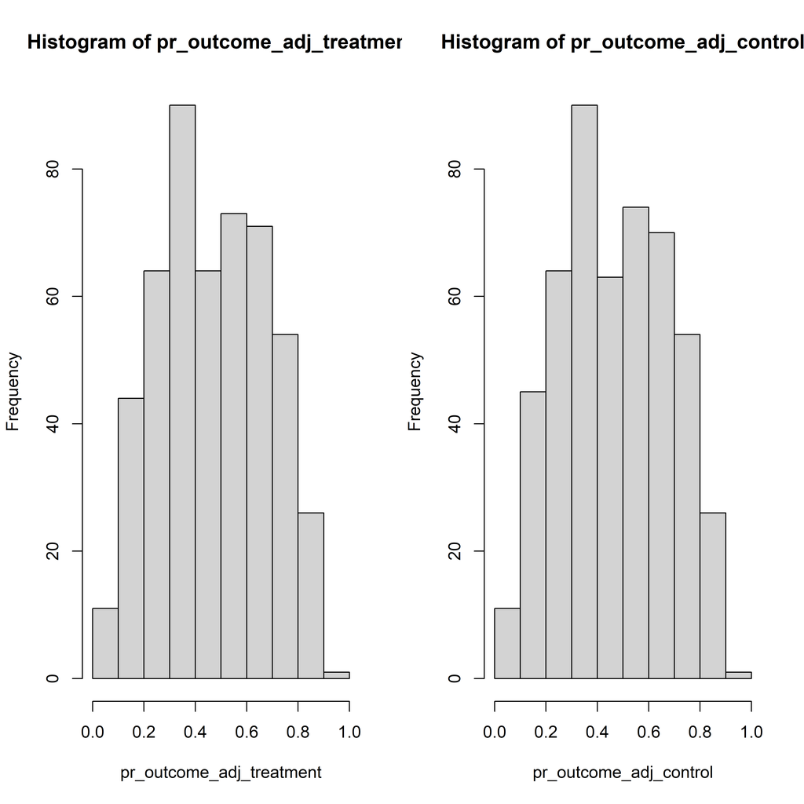

```r
pr_outcome_adj_control <-
  stats::predict(
    object = mrs_adjusted_logistic_glm,
    newdata =
      within(data = sim_miii,
             expr = {arm = "medical"}),
    type = "response"
  )

pr_outcome_adj_treatment <-
  stats::predict(
    object = mrs_adjusted_logistic_glm,
    newdata =
      within(data = sim_miii,
             expr = {arm = "surgical"}),
    type = "response"
  )

par(mfrow = c(1, 2))
hist(
  pr_outcome_adj_treatment,
  breaks = "fd"
)

hist(
  pr_outcome_adj_control,
  breaks = "fd"
)
```

### 5.3 Results: Adjusted

```r
rd_adjusted_result <-
  analysis_g_computation(
    data = sim_miii,
    formula = mrs_365d_binary ~ tx + age + male + hx_cvd + hx_hyperlipidemia +
      on_anticoagulants + on_antiplatelets + ich_location + ich_s_volume +
      ivh_s_volume + gcs_category,
    family = binomial(link = "logit"),
    estimand = "difference", # "ratio" or "oddsratio"
    treatment_column = "tx",
    se_method = "bootstrap", # "none" "influence" "score"
    verbose = TRUE # Needed for p-value, not CI
  )

with(
  data = rd_adjusted_result$result,
  expr = {
    c(
      "Estimate" = estimate,
      "SE" = se_boot_df_adjusted,
      "LCL" = lcl_bca_df_adjusted_0.95,
      "UCL" = ucl_bca_df_adjusted_0.95
    )
  }
)
```

```
##     Estimate           SE          LCL          UCL
##  0.001011054  0.042863944 -0.081745264  0.085222994
```

```r
boot_p_value(
  boot_object = rd_adjusted_result$boot_object,
  ci_method = "bca",
  null_value = 0,
  # Adjust CI width for DF in model
  var_adjust = rd_adjusted_result$result$variance_factor
)
```

```
## [1] 0.9669193
```

## 6 Comparing Analysis Methods:

- $Var(\theta) = (SE(\theta))^2$
- Relative Efficiency: $RE_{A/U} = Var(\theta_{U})/Var(\theta_{A})$
- Relative Change in Variance: $RCV_{A/U} = \frac{Var(\theta_{A}) - Var(\theta_{U})}{Var(\theta_{U})} = \frac{1}{RE_{A/U}} - 1$
- Relative Change in Precision: $RCP_{A/U} = \frac{1/Var(\theta_{A}) - 1/Var(\theta_{U})}{1/Var(\theta_{U})} = Var(\theta_{U})/Var(\theta_{A}) - 1 = RE_{A/U} - 1$